# Young Women’s Labour-Market Inclusion

Findings and cost of inaction, Ukraine

Hernando Grueso-Hurtado, PhD

UNICEF

November 2026

## Content

1 · The problem: NEET among young women

2 · Who is most affected

3 · From education to earnings

4 · The cost of the gender gap

5 · Conclusions and recommendations

Appendix

## Data sources

- **Multiple Indicator Cluster Survey (MICS) 2025/26**, State Statistics Service of Ukraine with UNICEF: 23,708 households, 37,315 household members, 8,213 women aged 15–49 selected for interview, and children 5–17. There is no men’s questionnaire. Main source for education, NEET and employment among young women, marriage, motherhood, disability, displacement, wealth and changes in households since the beginning of the conflict.
- **UNICEF Household Social and Economic Status Survey (HSESS)**, December 2023 to February 2024, Institute of Demography and Quality of Life Problems: 18,838 individuals in 8,024 households, all regions covered by the survey (Luhansk oblast is not included). Covers women and men: participation, employment, NEET, job quality, occupations, earnings and childcare.
- **SSSU Labour Force Survey 2021** (anonymised public-use file), collected in 2021: 265.6k interviews from 151.7k persons aged 15+. Shown for reference only.

# The problem

## 31% of women aged 18–24 are NEET

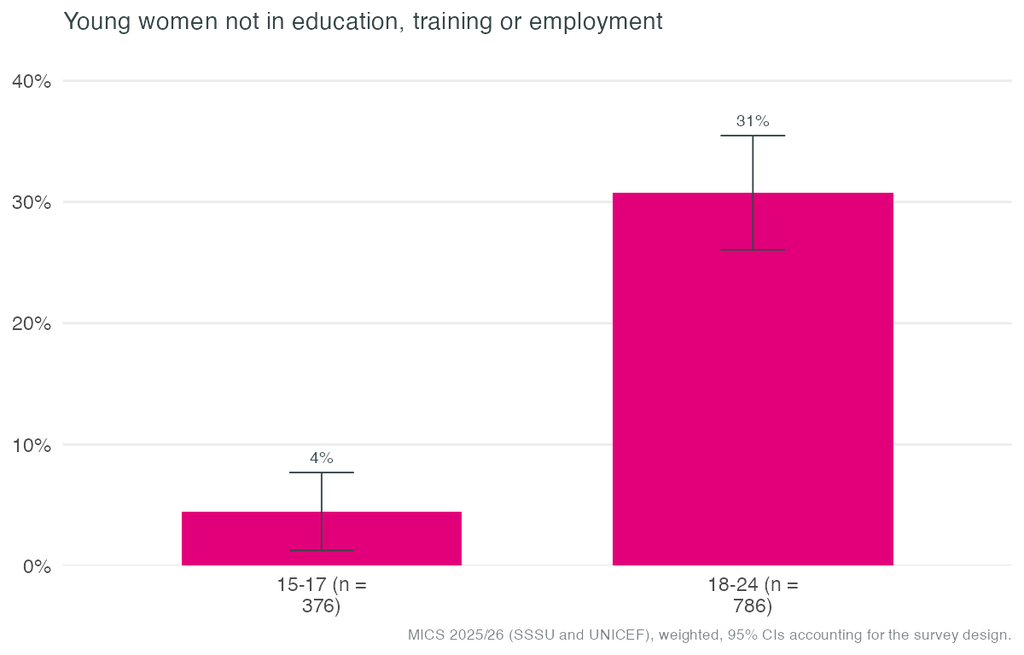

MICS 2025/26. NEET: not in education or training and not employed. At 15–17 the rate is 4%: almost all girls are still in education. The survey asks these questions to women from age 15, so NEET cannot be measured at 14.

## The gap with young men comes from education, not employment

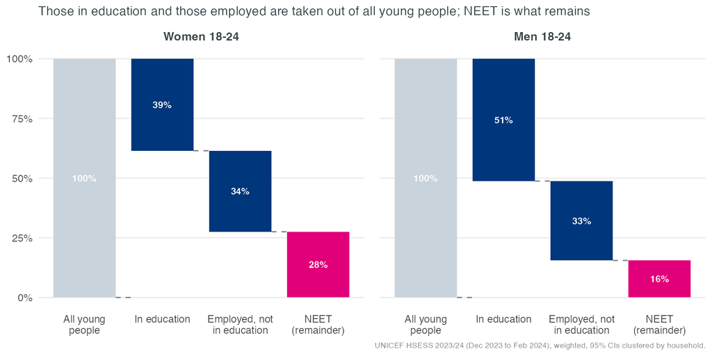

## At 14–17, almost all girls and boys are in school

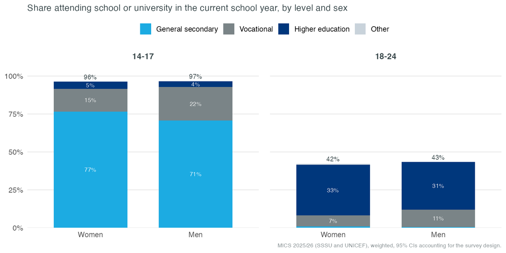

MICS 2025/26, household members attending in the current school year. Ages 14–17: girls 96%, boys 97%. Ages 18–24: women 42%, men 43%. School attendance is available from age 14; NEET and employment only from age 15. MICS does not show the gap in education at 18–24 that HSESS shows; the surveys differ in date, respondent and definition.

# Who is most affected

## Mothers and the poorest have the highest NEET rates

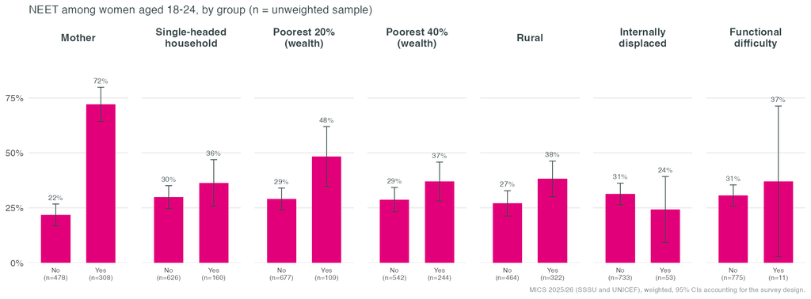

MICS 2025/26, women aged 18–24. Mothers 72% vs 22%; poorest fifth 48% vs 29%; single-headed households 36% vs 30%; internally displaced 24% vs 31%. Bars show 95% confidence intervals and the sample size; small groups should not be ranked.

## Among poor young mothers, NEET reaches 74% to 83%

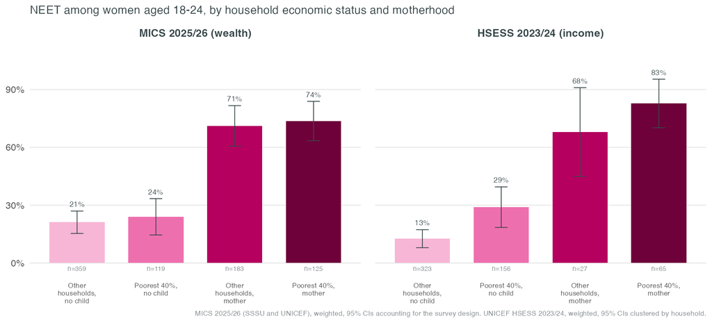

Women aged 18–24. Women with neither characteristic: 21% (MICS) and 13% (HSESS). Poor mothers are 16% of NEET young women in MICS and 30% in HSESS. Poorest 40% by wealth (MICS) or income per household member (HSESS).

## Disadvantages add up

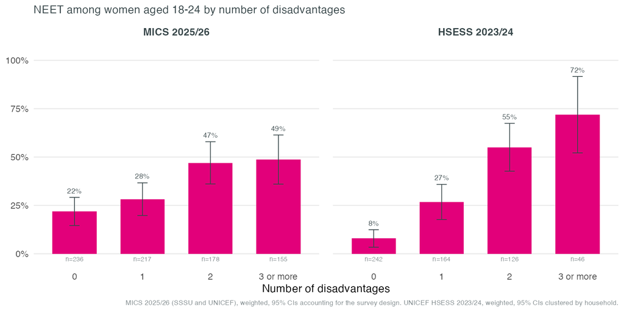

Women aged 18–24. With none of the five disadvantages, NEET is 22% (MICS) and 8% (HSESS); with three or more, 49% and 72%. Disadvantages: motherhood, poorest 40%, rural, displaced, single-headed household.

## Motherhood remains the main factor after adjustment

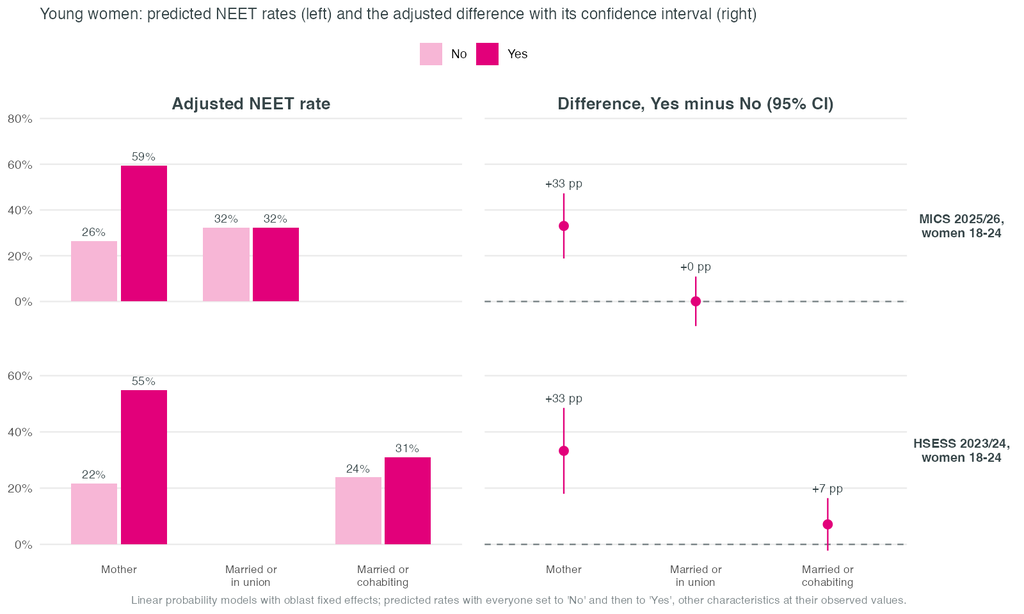

Women aged 18–24, both surveys. Left: predicted NEET rates for mothers and others, and for married women and others, holding age, area, education, income and displacement constant. Right: the difference with its 95% confidence interval. Associations, not causal effects.

## Why young women are not working or looking for work

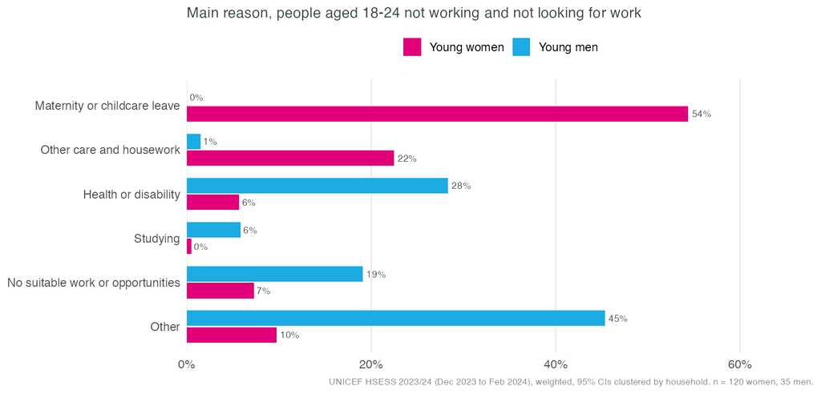

HSESS 2023/24, people aged 18–24 who were not employed and not looking for work. Maternity or childcare leave is shown separately from other care and housework.

## Childcare barriers differ by the child’s age

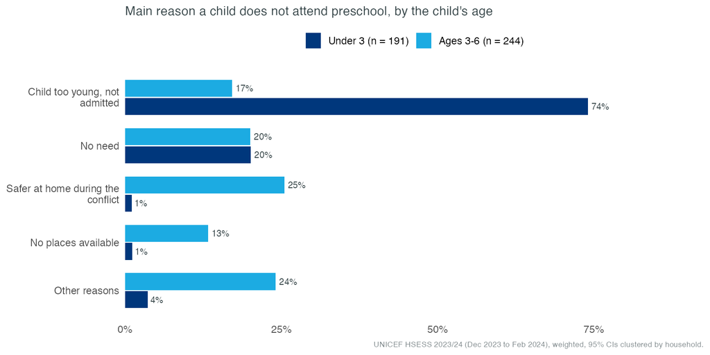

HSESS 2023/24: main reason a child does not attend preschool, for children under 3 and aged 3–6. Preschool attendance at ages 3–5 is 60% (MICS 2025/26).

# From education to earnings

## NEET falls with education

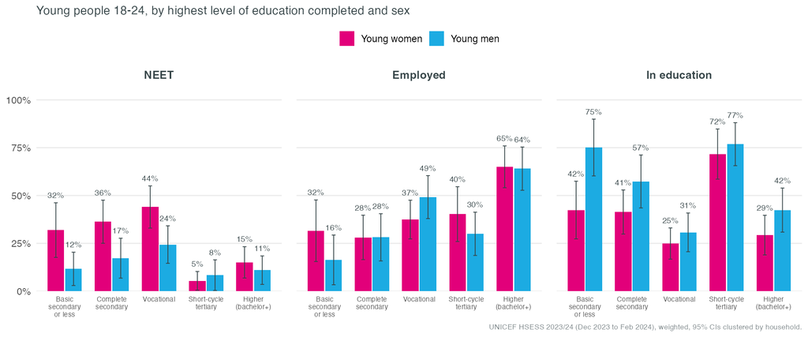

HSESS 2023/24, ages 18–24, by highest level completed. NEET among women: 15% with higher education, 36% with complete secondary. Many 18–24 year olds are still studying, so rates by level should be read together with the share in education.

## No significant NEET gap between vocational and secondary education

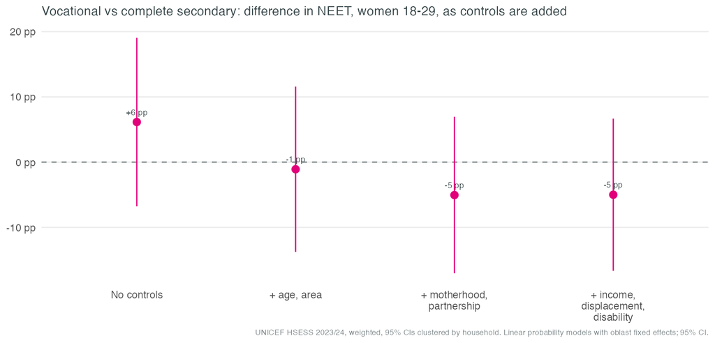

HSESS 2023/24, women aged 18–29. Each dot is a regression coefficient: the difference in the NEET rate between women with vocational and with complete secondary education (linear probability model, oblast fixed effects), with its 95% confidence interval, as controls are added. The difference is 6 pp without controls and -5 pp with all controls; no interval excludes zero, so the difference is not statistically significant in any specification. NEET by level: vocational 48%, complete secondary 44%, tertiary 30%.

## Women earn less than men at every level of education

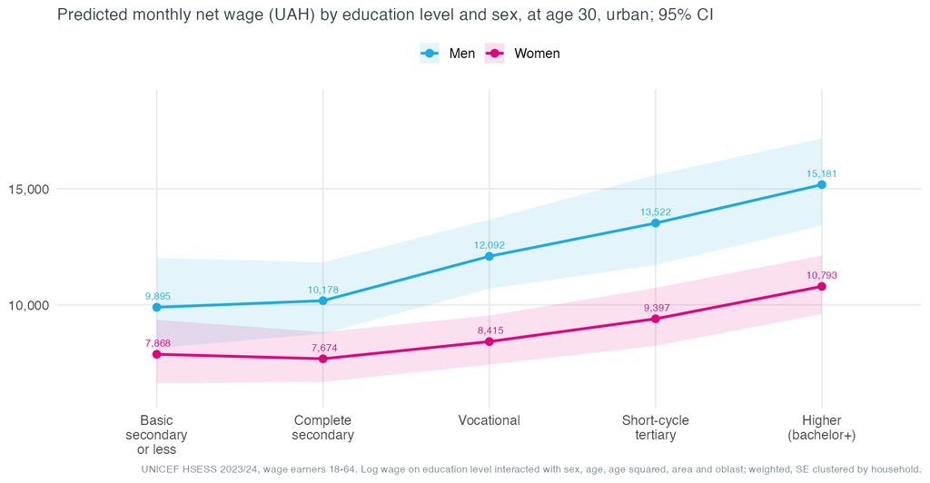

HSESS 2023/24, wage earners aged 18–64. Predicted net monthly wage at age 30 in an urban area. Gap at comparable age and area: 25% with complete secondary, 29% with higher education. Each additional year of education is associated with 5.8% higher wages for women and 7.2% for men. Not adjusted for hours, occupation or sector.

# The cost of the gender gap

## How the cost of the gender gap is calculated

| Step | What is used | Source |
| --- | --- | --- |
| **1. The gap** | 27.5% of women aged 18–24 are NEET, against 15.5% of men: a gap of 12.0 percentage points | HSESS 2023/24 |
| **2. How many women** | The gap applied to the 1,085,000 women aged 18–24 in the areas covered by the survey: about 130,000 more young women would be in work if the gap were closed | HSESS 2023/24 (population-scaled weights) |
| **3. What they would earn** | The wage predicted for each NEET young woman from her education, age and place of residence by a Mincer wage equation estimated on employed women: UAH 9,078 a month on average | HSESS 2023/24 |
| **4. Formal jobs** | 75% of the new jobs are formal, as among employed young women today | HSESS 2023/24 |
| **5. What the economy and the budget gain** | Economy: what employers would pay for this work (gross wage plus employer social contribution). Public revenues: income tax, military levy, employer social contribution (ESV) and VAT | Statutory rates |

The cost of inaction is the earning potential lost each year that the gap remains: how much more the economy and public revenues would receive if young women were NEET at the same rate as young men. Wages are from December 2023 to February 2024, so all comparisons use 2024 values. Assumptions, the wage equation and a sensitivity analysis are at the start of the appendix.

## Closing the gender gap would add UAH 20.5 billion a year to the economy and UAH 8.1 billion to public revenues

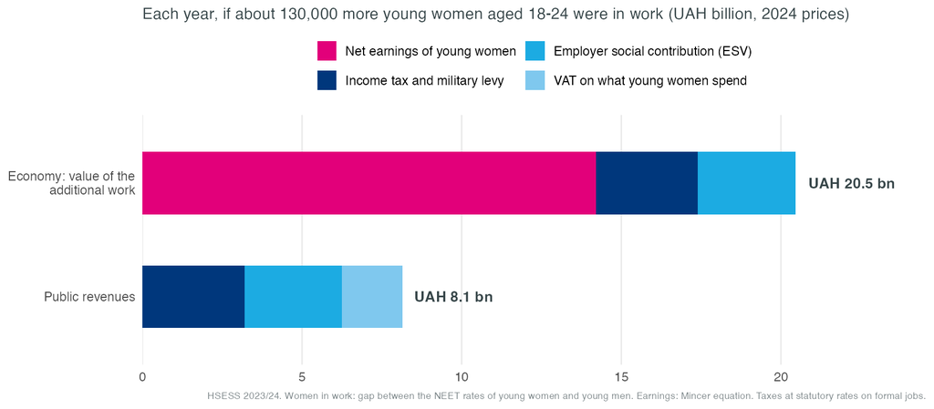

About 130,000 more young women in work, each earning UAH 9,078 a month on average (predicted by the wage equation). Public revenues: income tax and military levy UAH 3.2 billion, employer social contribution UAH 3.1 billion, VAT UAH 1.9 billion. Over a working life to age 60, each of these young women would generate about UAH 2.8 million for the economy and UAH 1.1 million in public revenues (present values at 5%).

## What this means for the budget

15%

of public spending on preschool education

UAH 8.1 billion a year against UAH 52.6 billion budgeted in 2024

46%

of state support to low-income families

UAH 8.1 billion a year against UAH 17.9 billion in 2024

3.4%

of public spending on health

UAH 8.1 billion a year against UAH 238.7 billion in 2024; 5.1% of the Programme of Medical Guarantees

Public revenues forgone each year the gender gap remains, compared with what the state spent on these services in 2024, the year the wages were collected. As a share of the whole economy the cost is about 0.27% of GDP (UAH 20.5 billion), and 2.3% of public spending on education. Sources: Ministry of Finance (2024 budget execution and 2025 budget overview), National Health Service of Ukraine, State Statistics Service of Ukraine, A Brighter Future (UNICEF Ukraine, 2024); full list in the appendix.

## How to read this estimate

**Is there demand for these workers?**

- Employers report record shortages: 69% of 469 industrial firms named a lack of workers as their main obstacle in May 2026 ([IER monthly enterprise survey, via Forbes Ukraine, 18 June 2026](https://forbes.ua/news/defitsit-robochoi-sili-v-ukraini-onoviv-istorichniy-rekord-i-syagnuv-69-opituvannya-ied-18062026-39747)), and 78% of employers reported a shortage in 2026, up from 60% a year earlier ([OLX Jobs survey, via Dengi.ua, 20 July 2026](https://dengi.ua/en/amp-page/career/9761562-labor-shortage-why-ukrainian-businesses-arent-hiring-foreign-workers)).
- At the end of June 2026 there were about 235,000 open vacancies against 93,000 registered unemployed ([State Employment Service, via RBC-Ukraine, 22 July 2026](https://www.rbc.ua/rus/news/persha-robota-molodi-k-derzhava-dopomagae-1783603871.html)).
- 38% of industrial firms had raised wages in 2026, by 11% on average ([IER, via Komersant, 18 August 2026](https://komersant.ua/en/kadrovij-golod-mobilizacziya-ta-pidvishhennya-zarplat-yak-promislovist-ukraini-vizhivala-u-lipni-2026-roku/)), and half of the employers in a Helvetas and State Employment Service survey planned to hire women for traditionally male-dominated professions in 2026 ([Kyiv Independent, 2 March 2026](https://kyivindependent.com/war-has-drained-ukraines-workforce-but-women-and-veterans-are-stepping-in-to-fill-the-void)).
- But demand is uneven: only 32% of businesses surveyed by the State Employment Service were considering hiring in 2026 ([Censor.net, 26 August 2026](https://censor.net/en/resonance/4020243/why-is-the-number-of-people-in-the-informal-labour-market-growing-in-ukraine)), and survey-based unemployment was 15.5% in March 2026 ([Centre for Economic Strategy data, via OSW, 12 May 2026](https://www.osw.waw.pl/en/publikacje/osw-commentary/2026-05-12/high-unemployment-and-labour-shortages-paradoxes-ukraines)).
- So demand exists, but jobs have to be reachable for young mothers: location, hours, childcare and skills matter as much as the number of vacancies.

**What the estimate does and does not capture**

*Likely to understate the cost:* it counts only earnings and taxes; it leaves out effects on children, on young women’s future careers (lost experience), on employers, and the wider economy; it counts only the gap with young men, not all NEET young women.

*Likely to overstate it:* it assumes jobs are available at the wage of employed women with the same education, age and location, that new workers do not displace others, and that NEET women would earn as much as employed women with the same profile.

*How to use it:* as the order of magnitude of what is at stake, with a range rather than a single number, and as the benchmark against which the cost of support services can be judged.

## Mothers are 42% of NEET young women

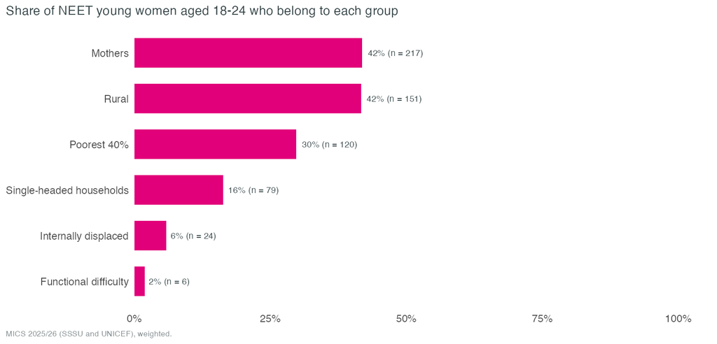

MICS 2025/26, women aged 18–24. Groups overlap, and 68% of NEET young women belong to at least one of the first five. Mothers are the largest identifiable group, so support that works for young mothers addresses the largest part of the gap.

## Motherhood accounts for about 85% of the gender gap

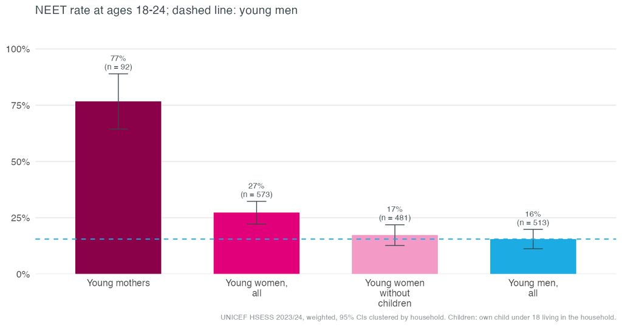

HSESS 2023/24, ages 18–24. NEET is 77% among young mothers and 17% among young women without children, against 16% among young men. If young mothers were NEET at the same rate as other young women, the NEET rate of young women would fall from 27% to 17%, closing about 85% of the gap with young men. This is arithmetic on the survey, not a causal estimate, but it shows that support for young mothers is where most of the gap, and most of its cost, can be closed.

## Two existing programmes: what they offer

[output not shown]

Sources: youth hiring compensation, [State Employment Service, via RBC-Ukraine, 22 July 2026](https://www.rbc.ua/rus/news/persha-robota-molodi-k-derzhava-dopomagae-1783603871.html) (amount, duration, eligibility and reach); eYasla, [Government of Ukraine, 14 January 2026](https://www.kmu.gov.ua/news/z-1-sichnia-v-ukraini-startuvala-derzhavna-prohrama-pidtrymky-batkiv-iaki-pratsiuiut-ieiasla) (amount, eligibility and permitted uses); allowance before age one, [Fakty, 26 January 2026](https://fakty.com.ua/ua/ukraine/20260126-7-000-gryven-na-dytynu-do-roku-umovy-ta-poryadok-vyplat/). These are the two programmes used to illustrate the break-even approach on the next slide: both are in place today, both pay only while a young woman is in work, and each responds to one of the main findings. The same approach can be applied to other programmes once their costs are known.

## Would existing programmes pay for themselves?

Each young woman who moves into work generates about **UAH 62,505 a year in public revenues** and UAH 156,915 for the economy. Two existing programmes pay only while a young woman is in work, so whether they pay for themselves depends on one question: **how many of the women they support would not have been working without them?** The table shows the minimum share needed, using each programme’s official 2026 amounts.

| Programme | Cost per woman (UAH) | Years she stays in work | Public revenues only | Value to the economy |
| --- | --- | --- | --- | --- |
| Youth hiring compensation: 50% of the minimum wage for 6 months (State Employment Service) | 25,944 | 1 | 42% | 17% |
| Youth hiring compensation: 50% of the minimum wage for 6 months (State Employment Service) | 25,944 | 3 | 15% | 6% |
| eYasla: UAH 8,000 a month from the child’s first to third birthday (24 months) | 187,429 | 2 | 154%: not reachable | 61% |
| eYasla: UAH 8,000 a month from the child’s first to third birthday (24 months) | 187,429 | 5 | 66% | 26% |

Years in work: the shorter horizon is built into each programme (the employer must keep the job for 12 months to receive the full compensation; eYasla pays only while the mother works full time, for two years); the longer one is illustrative (a first job that lasts three years; a mother who stays in work until her child starts school at six). Reading the table: the youth hiring compensation pays for itself through public revenues if about 42% of subsidised hires would not have happened without it and last a year (15% if they last three years). eYasla cannot pay for itself through public revenues during the payment period, even if every mother is additional; it pays for itself in value to the economy if about 61% of supported mothers would not otherwise have worked, or 26% if they stay in work for five years, before counting any benefits for children. Neither programme has been evaluated, so these shares are tests to apply, not results; eYasla started in January 2026 and could be evaluated by comparing employment of eligible mothers before and after it. Benefits use 2023/24 wages and costs are 2026 amounts, so the shares are conservative. Sources: programme amounts from the [State Employment Service, via RBC-Ukraine (22 July 2026)](https://www.rbc.ua/rus/news/persha-robota-molodi-k-derzhava-dopomagae-1783603871.html) and the [Government of Ukraine (14 January 2026)](https://www.kmu.gov.ua/news/z-1-sichnia-v-ukraini-startuvala-derzhavna-prohrama-pidtrymky-batkiv-iaki-pratsiuiut-ieiasla); benefits from this analysis, calculated step by step in the appendix.

# Conclusions and recommendations

## Where to invest: three areas

|  | Investment area | Who it reaches | How many NEET young women | What the data show | Existing mechanisms to build on |
| --- | --- | --- | --- | --- | --- |
| **1** | **Care support for young mothers**: childcare places for children under 3, flexible and family-friendly work | Young mothers aged 18–24 | 42%, about 125,000 | Motherhood accounts for about 85% of the gender gap (HSESS); NEET is 72% among young mothers (MICS) | eYasla; preschool expansion; employers’ family-friendly policies (Inclusive Access and Navigation) |
| **2** | **First work experience** at the exit from education: internships, apprenticeships, first-job support | Young women without children leaving education | 58%, about 174,000 | Women and men work at the same rate; the gap opens in the transition; only 11% of NEET young women are looking for work | Youth hiring compensation; State Employment Service; employer partnerships (Learning-to-Earning) |
| **3** | **Linking social assistance and employment** for the poorest and single-headed households | Young women in the poorest 40% or in single-headed households | 38%, about 112,000 | Poverty compounds motherhood: 16% of NEET young women are poor mothers | Social assistance registries and case management linked to the State Employment Service |

Areas are ranked by how much of the gender gap they can address. Areas 1 and 2 split NEET young women into mothers and women without children; area 3 cuts across both. Shares of NEET young women aged 18–24 from MICS 2025/26, applied to the number of NEET young women in the areas covered by HSESS 2023/24. Choosing specific programmes within each area needs their components, costs and coverage, to be agreed with the country office.

## Key messages

**1. The problem is large.** 31% of women aged 18–24 are NEET (MICS 2025/26); in HSESS, 28% of women against 16% of men.

**3. Motherhood is the main factor.** NEET is 72% among young mothers against 22% among other young women, the difference remains after adjusting for other characteristics, and motherhood accounts for about 85% of the gender gap.

**4. Poverty compounds it.** Among poor young mothers NEET reaches 74% to 83%; displacement is not associated with higher NEET.

**5. The gender gap is costly.** Closing it would bring about 130,000 more young women into work, adding UAH 20.5 billion a year to the economy and UAH 8.1 billion to public revenues: about 15% of what the state spends on preschool education, or 46% of its support to low-income families.

**6. Support can pay back through the budget.** Each young woman who moves into work returns about UAH 62,505 a year in public revenues: the youth hiring compensation pays for itself if about 42% of subsidised hires are additional, while eYasla needs to be judged on its value to the economy and to children.

## Priority 1: Learning-to-Earning (First Experience, Earning Engine)

[output not shown]

## Priority 2: Inclusive Access and Navigation (protection and employment)

[output not shown]

# Appendix

## Cost of the gender gap: key assumptions

[output not shown]

## Value of one young woman in work, step by step

| Step | Calculation | UAH a year |
| --- | --- | --- |
| **1. Net earnings** | Predicted net wage of NEET young women (Mincer equation), UAH 9,078 a month × 12 | 108,935 |
| **2. Gross wage** | Net ÷ (1 − 18% income tax − 5% military levy) | 141,474 |
| **3. Income tax and military levy** | 75% of jobs are formal × gross wage × 23% | 24,523 |
| **4. Employer social contribution (ESV)** | 75% formal × gross wage × 22% | 23,457 |
| **5. VAT on what she spends** | 80% of net earnings spent × 20/120 (VAT included in prices) | 14,525 |
| **Public revenues** | Steps 3 + 4 + 5 | **62,505** |
| **Value to the economy** | Steps 1 + 3 + 4: what employers pay for her work (gross wage plus ESV for formal jobs, net wage for informal ones) | **156,915** |

The two totals are alternative perspectives, not additive: taxes and contributions appear in both. Value to the economy is a lower bound on what her work produces, since it leaves out the return to employers. The military levy is the 5% rate in force since December 2024; VAT assumes 80% of earnings is spent on goods and services at the standard rate. Break-even share for a programme = cost per woman ÷ (annual value × years in work, discounted at 5%); for example, UAH 25,944 ÷ UAH 62,505 = 42% for the youth hiring compensation over one year.

## Budget comparators and sources

| Compared with (2024) | UAH bn | Measured against | Share | Source |
| --- | --- | --- | --- | --- |
| GDP | 7,658.7 | Economy | 0.27% | State Statistics Service of Ukraine, GDP estimate for 2024 (31 March 2025) |
| Public revenues: state budget taxes and fees plus social contributions | 3,646.1 | Revenues | 0.22% | Ministry of Finance, 2024 budget execution: over UAH 3.1 trillion in taxes, fees and other payments (general and special funds) and UAH 546.1 billion in ESV |
| Public spending on health | 238.7 | Revenues | 3.4% | Ministry of Finance, 31 January 2025: health spending in 2024 (all budgets) |
| Programme of Medical Guarantees | 159.0 | Revenues | 5.1% | National Health Service of Ukraine, 1 January 2024: budget of the 2024 programme (over UAH 159 billion) |
| Public spending on education | 348.4 | Revenues | 2.3% | Ministry of Finance: education spending in 2024 (all budgets) |
| Public spending on preschool education | 52.6 | Revenues | 15.5% | A Brighter Future (UNICEF Ukraine, 2024): amount budgeted for 2024 |
| State support to low-income families | 17.9 | Revenues | 45.5% | Ministry of Finance, State Budget 2025 overview: UAH 19.7 billion in 2025, UAH 1.8 billion more than in 2024 |

Value to the economy is compared with GDP; public revenues forgone with the other items. Health and education spending cover all budgets (state and local); support to low-income families is the 2024 amount implied by the 2025 budget overview (UAH 19.7 billion in 2025, UAH 1.8 billion more than in 2024). Local budgets receive part of the personal income tax, so comparisons with state budget items slightly overstate the share.

## Sensitivity: changing one assumption at a time

| Assumption | Value | Women in work | Economy (UAH bn a year) | Public revenues (UAH bn a year) |
| --- | --- | --- | --- | --- |
| Central estimate | Gender gap; Mincer wage; formality of employed young women | 130,300 | 20.5 | 8.1 |
| Wage | 25th percentile of employed women 18-24 (UAH 7,000) | 130,300 | 15.8 | 6.3 |
| Wage | Median of employed women 18-24 (UAH 10,000) | 130,300 | 22.5 | 9.0 |
| Formality | 62%, women without tertiary education | 130,300 | 19.4 | 7.1 |
| Formality | 86%, women with tertiary education | 130,300 | 21.3 | 9.0 |
| Women in work | Only NEET young women already looking for work (11% of them) | 34,000 | 5.3 | 2.1 |
| Women in work | Gap measured with the MICS NEET rate for women (30.8%) | 165,400 | 26.0 | 10.3 |

Each row changes one assumption and keeps the others at their central values. The central estimate uses the gap measured in HSESS, the only survey that covers both young women and young men.

## Wage equation behind the cost of inaction

Step 1 · Estimation on employed women

ln *w*<sub>*i*</sub> = α + Σ<sub>*k*</sub> β<sub>*k*</sub> Educ<sub>*ik*</sub> + γ<sub>1</sub> Age<sub>*i*</sub> + γ<sub>2</sub> Age<sub>*i*</sub><sup>2</sup> + δ Rural<sub>*i*</sub> + μ<sub>oblast(*i*)</sub> + ε<sub>*i*</sub>

*w*<sub>*i*</sub>: monthly net wage of employed woman *i* · Educ<sub>*ik*</sub>: highest level completed (reference: basic secondary or less) · μ: oblast effects

Step 2 · Prediction for each NEET young woman

ŵ<sub>*j*</sub> = exp( *x*<sub>*j*</sub>′ β̂ ) × *S*, *S* = Σ<sub>*i*</sub> ω<sub>*i*</sub> exp( ε̂<sub>*i*</sub> ) / Σ<sub>*i*</sub> ω<sub>*i*</sub>

*x*<sub>*j*</sub>: her own education level, age, area and oblast · *S*: smearing factor that converts predicted log wages back to UAH · ω<sub>*i*</sub>: survey weights

**Sample**  
Employed women aged 18–64 with a reported wage, HSESS 2023/24: n = 3,112, R² = 0.32. Predictions for 161 NEET women aged 18–24.

**Estimation**  
Weighted least squares with survey weights. Coefficients in the next appendix slide.

**Limits**  
No adjustment for hours, occupation or sector, and no correction for selection into work: NEET women may earn less than employed women with the same profile.

## Wage equations behind the education and gender results

Returns to a year of education · estimated separately for women and men

ln *w*<sub>*i*</sub> = α + ρ *S*<sub>*i*</sub> + γ<sub>1</sub> Age<sub>*i*</sub> + γ<sub>2</sub> Age<sub>*i*</sub><sup>2</sup> + μ<sub>oblast(*i*)</sub> + ε<sub>*i*</sub>

*S*<sub>*i*</sub>: years of education implied by the highest level completed (9, 11, 12, 13, 15 or 17) · Return per year = exp(ρ) − 1: 5.8% for women, 7.2% for men · Wage earners aged 18–64 · Standard errors clustered by household

Wages by education level and sex · women and men pooled

ln *w*<sub>*i*</sub> = α + Σ<sub>*k*</sub> β<sub>*k*</sub> Educ<sub>*ik*</sub> + λ Woman<sub>*i*</sub> + Σ<sub>*k*</sub> θ<sub>*k*</sub> (Educ<sub>*ik*</sub> × Woman<sub>*i*</sub>) + γ<sub>1</sub> Age<sub>*i*</sub> + γ<sub>2</sub> Age<sub>*i*</sub><sup>2</sup> + δ Rural<sub>*i*</sub> + μ<sub>oblast(*i*)</sub> + ε<sub>*i*</sub>

Adjusted gap at education level *k* = 1 − exp(λ + θ<sub>*k*</sub>), shown at age 30 in an urban area · Wage earners aged 18–64 · Neither equation adjusts for hours, occupation or sector, or for selection into work

## Wage equation for the cost of inaction: coefficients

| Term | Coefficient | SE | p |
| --- | --- | --- | --- |
| Constant | 8.456 | 0.110 | <0.001 |
| Education: Complete secondary | -0.010 | 0.044 | 0.817 |
| Education: Vocational | 0.087 | 0.039 | 0.027 |
| Education: Short-cycle tertiary | 0.181 | 0.046 | <0.001 |
| Education: Higher (bachelor+) | 0.323 | 0.038 | <0.001 |
| Age | 0.029 | 0.00504 | <0.001 |
| Age squared | -0.00042 | 0.00006 | <0.001 |
| Rural | -0.212 | 0.019 | <0.001 |

Dependent variable: log of monthly net wage, employed women aged 18–64, HSESS 2023/24. Reference education level: basic secondary or less. Oblast effects not shown.

## How this builds on earlier investment cases

|  | A Brighter Future (UNICEF Ukraine, 2024) | This analysis |
| --- | --- | --- |
| **Focus** | Early childhood development: children under six | Young women aged 18–24 who are not in education, employment or training |
| **Question** | Returns to scaling up childcare, preschool, health, social protection and WASH services to 2050 | Who is excluded, why, and what the gender gap costs the economy and public revenues each year |
| **Data** | National statistics, mostly from before 2022, and regional assumptions | Microdata collected since 2022: MICS 2025/26 and HSESS 2023/24 |
| **Link** | Estimates that expanding childcare would allow caregivers, mainly women, to return to work | Measures that link directly: motherhood and childcare are the main reasons young women are out of work |

The two are complementary: the earlier case argues for expanding early childhood services; this one identifies the young women who would use them and what their exclusion costs. Both use a 5% social discount rate.

## Age groups

| Age group | Used for | Why |
| --- | --- | --- |
| **18–24** | Main group: NEET, employment, earnings, cost of inaction | In line with government statistics and UNICEF programming |
| **15–17** | NEET and employment among the younger group | MICS asks the NEET questions to women aged 15–24; HSESS asks employment questions from age 15 |
| **14–17** | School attendance | Available for all household members in both surveys |

MICS 2025/26 has no men’s questionnaire, so NEET and employment in MICS refer to women; comparisons between women and men use HSESS 2023/24 and, for school attendance, the MICS household roster.

## Variables and definitions (1/2)

| Concept | Definition | MICS 2025/26 | HSESS 2023/24 | LFS 2021 |
| --- | --- | --- | --- | --- |
| **In education** | Attending school or university in the current school year | ED9 (members 3–24); NE3 (women 15–24) | IND_A9 | reason_inactiv = 2 (inactive students) |
| **Employed** | Worked at least one hour for pay or profit in the reference week, or temporarily absent; production for own household use only is not counted | NE8–NE11, NE20–NE21 (women 15–24) | IND_B1 | labour_force = 1 |
| **NEET** | Not in education or training and not employed | NEET module (women 15–24) | IND_A9, IND_B1 | labour_force, reason_inactiv (upper bound) |
| **Labour-force participation** | Employed, or looking for work or starting a business | not available | IND_B1, IND_B21 | labour_force 1–2 |
| **Informal employment** | Verbal agreement, unregistered own-account work, or family farm work for sale | not available | IND_B3_1 | informal_empl = 1 |
| **Mother** | Has given birth (MICS) or lives with own child under 18 (HSESS) | CEB | household roster (IND_A1, ages) | not available |

## Variables and definitions (2/2)

| Concept | Definition | MICS 2025/26 | HSESS 2023/24 | LFS 2021 |
| --- | --- | --- | --- | --- |
| **Care work** | Caring for children or the sick in the past week (5–17); daily care of own children | CL11E, CL11F | IND_B28_1 | reason_inactiv = 3 (proxy) |
| **Internally displaced** | Self-reported IDP status | WB10A | IND_A19 | not available |
| **Disability** | Washington Group functional difficulty (18–49); any household member with disability | AF module | D1_Mult3/4 | not available |
| **Economic status** | Wealth quintile; household income per member | windex5 | V1 / household size | not available |
| **Years of education** | Years implied by the highest level completed (9 basic secondary, 11 complete secondary, 12 vocational, 13 short-cycle, 15 bachelor, 17 master) | welevel | IND_A7 | education |

## Key variables (1/2)

| Concept | Use | MICS 2025/26 | HSESS 2023/24 | LFS 2021 |
| --- | --- | --- | --- | --- |
| Age | Groups 15-17, 18-24; 15-29 for NEET | HL6; WB4 (women) | IND_A2 age in years | age_gr (bands) |
| Sex | Breakdown by sex | HL4 (household members) | IND_A3 | sex |
| Survey design | Weighted estimates | hhweight, wmweight, fsweight; psu; stratum | Final weight; household key | weight_year; kod_res |
| Region / area | Regional and urban/rural breakdown | HH7 oblast; macroregion; HH6 | OBLAST; SETTL_TYPE | rg; tp_ar |
| Displacement | Breakdown by displacement | WB10A IDP status; PE3 household moved | IND_A19 IDP status | not available |
| Disability | Breakdown by disability | disability (functioning, 18-49) | D1_Mult3/4 household member | not available |
| Marital status | Household formation | MSTATUS | IND_A6 | marital_st |
| Motherhood | Breakdown by motherhood | CEB children ever born; WDOBFC | Own child under 18 (roster) | not available |
| Care work | Care responsibilities | CL11E/F caring for children or the sick (5-17) | IND_B28_1 daily care of own children | reason_inactiv = 3 (proxy) |
| Childcare access | Preschool attendance | ED9, ED10A (ages 3-5) | IND_A14 reason not attending | not available |
| Economic status | Breakdown by income or wealth | windex5 wealth quintile; PE20 income | V1 household income per member | not available |

## Key variables (2/2)

| Concept | Use | MICS 2025/26 | HSESS 2023/24 | LFS 2021 |
| --- | --- | --- | --- | --- |
| Changes since 2022 | Household context | PE3 moved; PE5 dwelling damaged; PE12 members separated | not available | not applicable |
| Education level | Education-to-work transition | welevel; ED10A level attended | IND_A7 | education; special_dipl |
| In education | School attendance, NEET | ED9 (members 3-24); NE3 (women 15-24) | IND_A9; IND_A10 type | reason_inactiv = 2 |
| Training | NEET | NE6 courses or training (women 15-24) | not available | not available |
| Employment | Employment, NEET | NE8-NE11, NE20-NE21 (women 15-24) | IND_B1 | labour_force |
| Job search | Unemployment, participation | not available | IND_B21 | labour_force = 2 |
| Reason not working | Reasons for inactivity | not available | IND_B24 | reason_inactiv |
| Occupation / sector | Occupational distribution | not available | IND_B6_2; IND_B5_2 | occupation |
| Job quality | Informality, hours | not available | IND_B3_1; IND_B9_1; IND_B10_1 | informal_empl; actual_duration |
| Earnings | Wage differences, costing | not available | IND_V1_1_1 (wages) | not available |

Variable codes as in each questionnaire. Full list of variables in every file: output/inventory/variable_report.xlsx.

## Status at 15–17 and 18–24 by sex (HSESS)

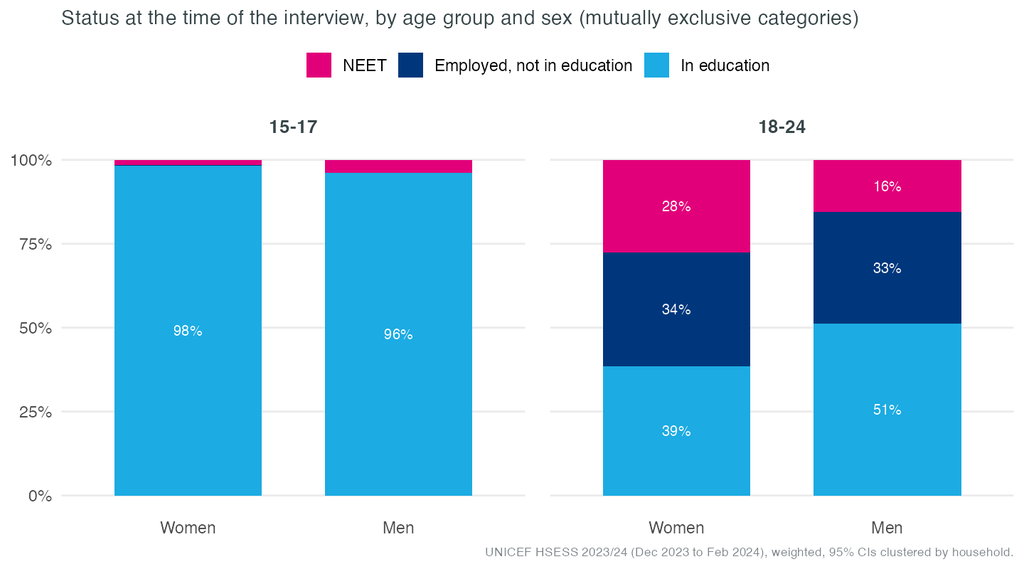

## Young women by age: education, training, employment, NEET (MICS)

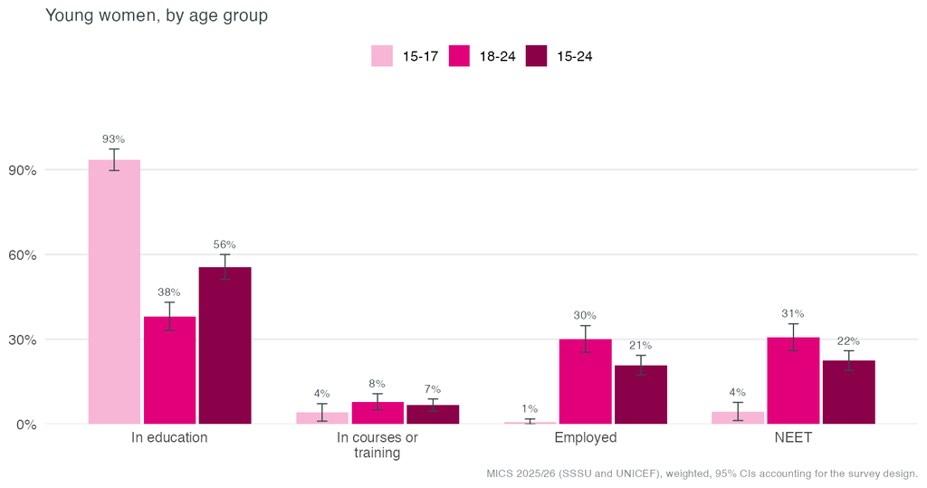

## NEET by group, women and men aged 18–24 (HSESS)

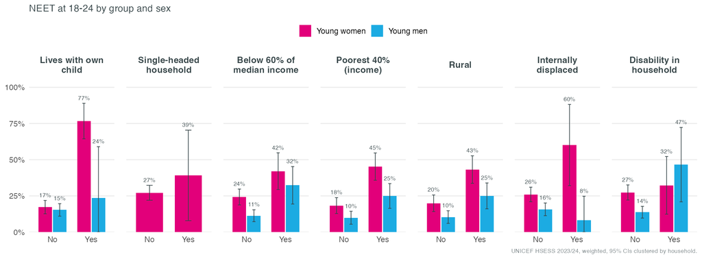

HSESS 2023/24. Below 60% of median income: women 42% against 24%. Single-headed households: 39% against 27%.

## Children in poor households, by the young woman’s NEET status (MICS)

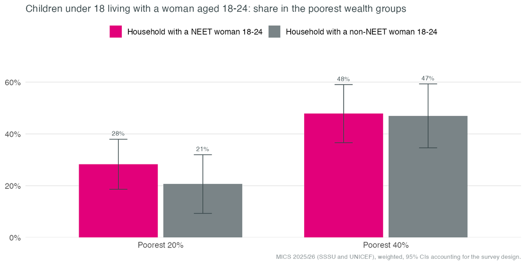

MICS 2025/26, children under 18 living with a woman aged 18–24. In the poorest 40%: 48% where she is NEET and 47% where she is not. The two are similar: children living with young women are more often in poor households regardless of her NEET status.

## Marital status and motherhood, women 18–24 (MICS)

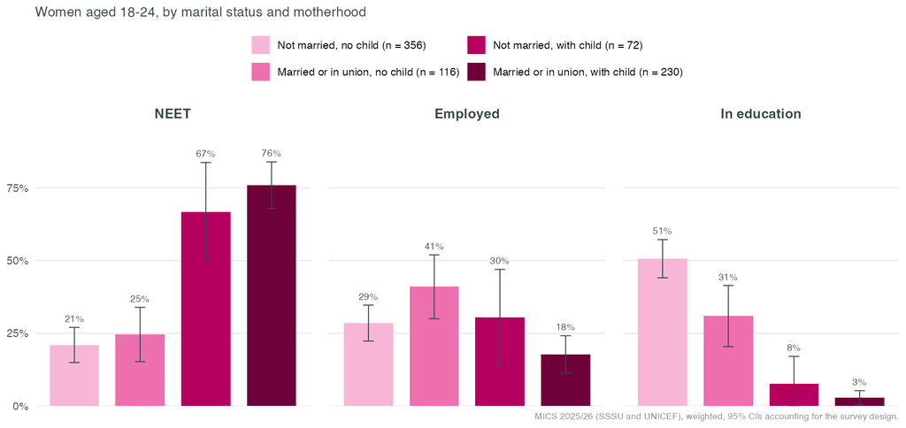

## Motherhood and partnership, women 18–24 (HSESS)

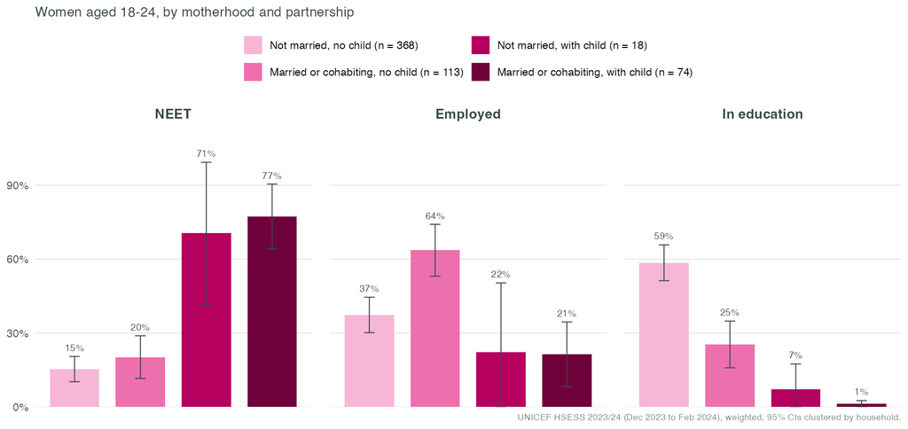

## Daily childcare and NEET at 18–24 (HSESS)

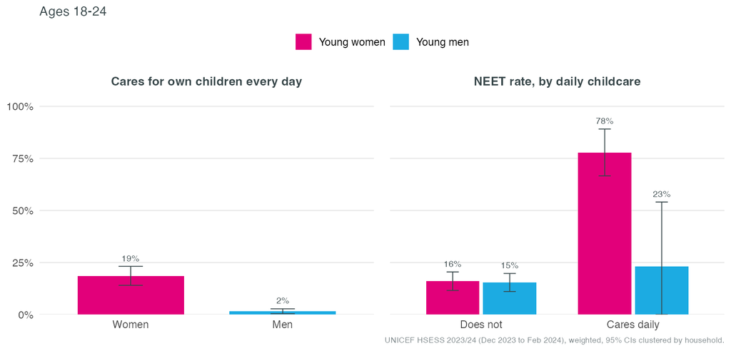

Daily care of own children: women 19%, men 2%. NEET among women who care daily: 78%; among others: 16%.

## Care work among adolescents aged 12–17 (MICS)

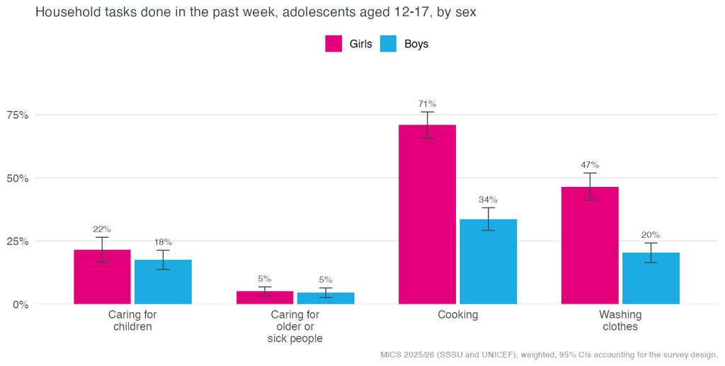

Cared for children in the past week: girls 22%, boys 18%.

## Preschool attendance by age (MICS)

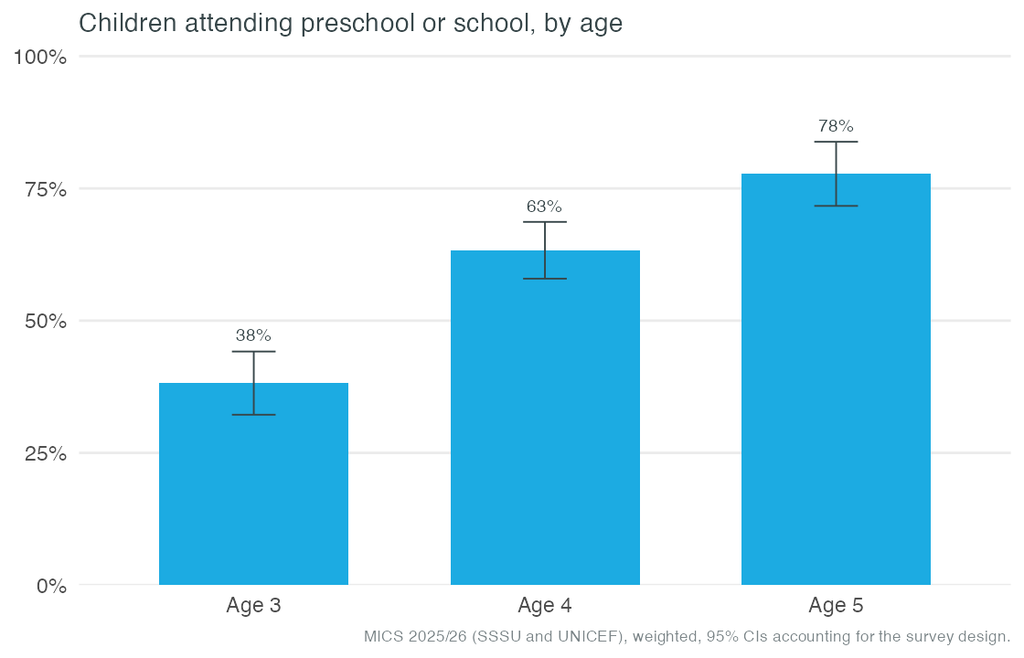

## Reasons for not attending preschool, all children (HSESS)

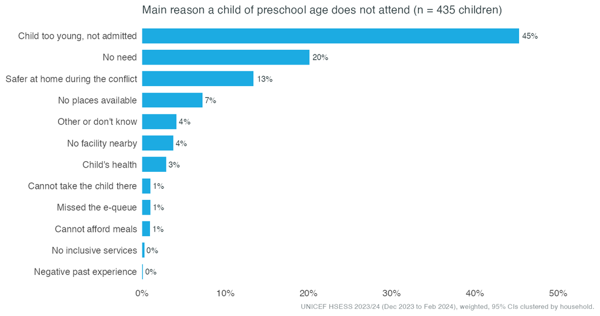

## NEET by macroregion and wealth, women 18–24 (MICS)

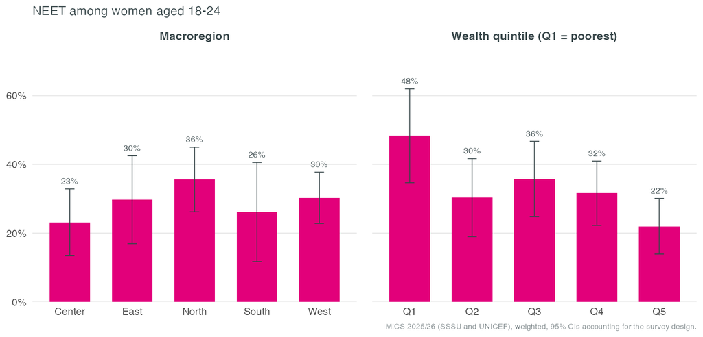

## NEET by household changes since the beginning of the conflict (MICS)

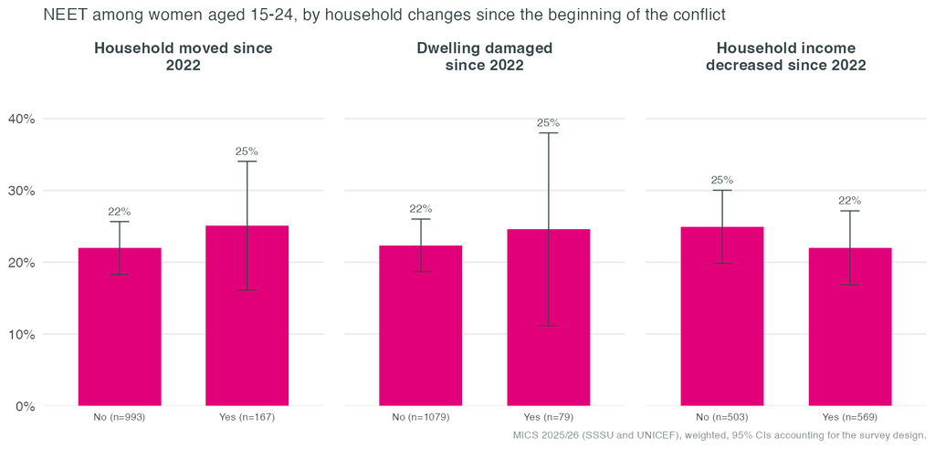

## Households since the beginning of the conflict (MICS)

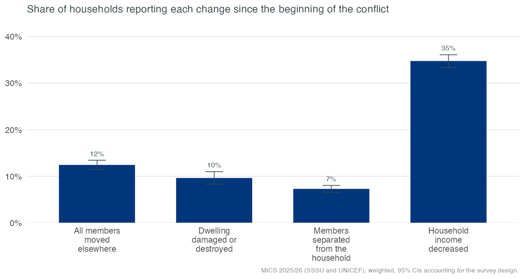

Moved: 12%. Lower income: 35%.

## NEET and employment by education, women 18–24 (MICS)

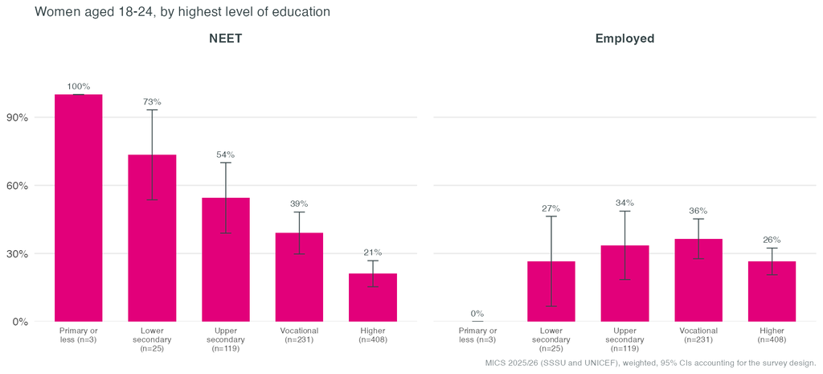

## Vocational graduates aged 18–29: profile (HSESS)

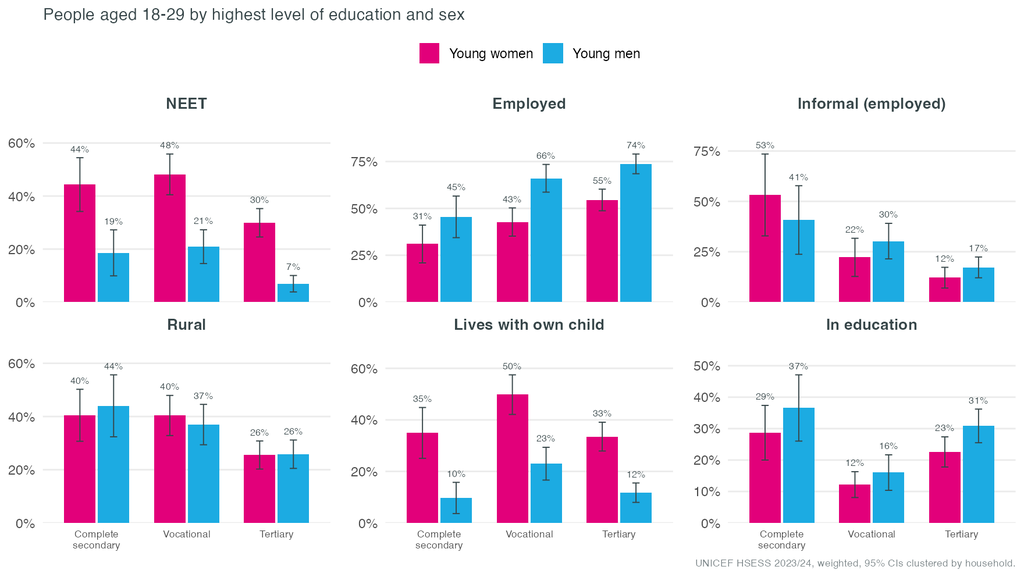

## Sectors of employed vocational graduates aged 18–29 (HSESS)

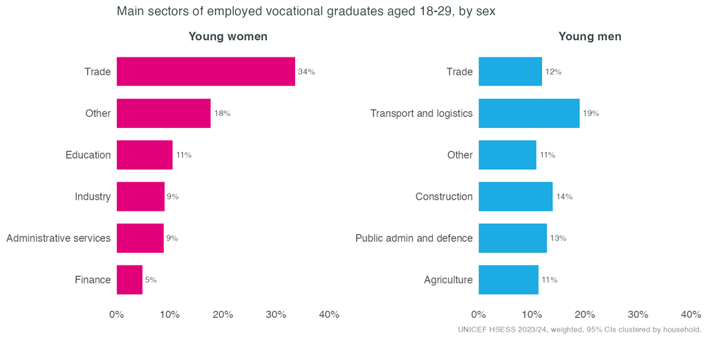

## In education by type of institution (HSESS)

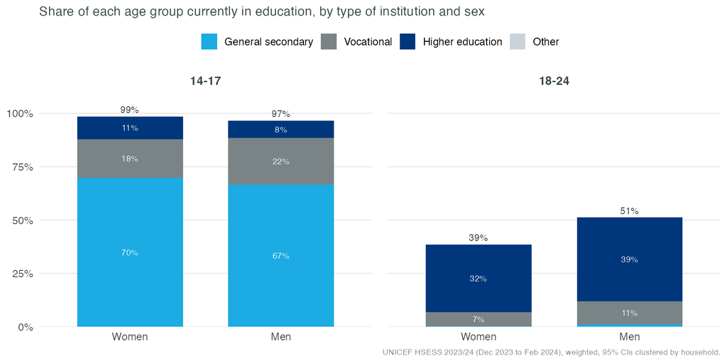